# Project2

himanshu yadav

2024-05-13

# Importing required libraries

```r
library(tidyverse)    # ggplot(), %>%, mutate(), and friends
library(scales)       # Format numbers with functions like comma(), percent(), and dollar()
library(broom)        # Convert models to data frames
library(modelsummary) # Side-by-side regression tables
library(foreign)   # for importing stata data
library(readr)
library(haven)
library(modelsummary)
library(stargazer)
library(tidyverse)
```

# Importing dataset “INJURY”

```r
dataset <- read_dta("C:/Github rep/Impact_Assesment-Project/Project_2-Impact_of_Workers'_Compensation_Policy_Change_on_Benefit_Duration/INJURY.DTA")
```

# Cleaning the data so that it only includes rows from (ky == 1)

```r
injury <- dataset %>% filter(ky==1)
```

# Renaming the columns

```r
injury <- injury %>% rename(duration = durat, log_duration = ldurat,after_1980 = afchnge)
```

Viewing the dataset

```r
injury
```

| duration | after_1980 | highearn | male | married | hosp | indust | injtype | age | prewage | totmed | injdes | benefit | ky | mi | log_duration | afhigh | lprewage | lage | ltotmed | head | neck | upextr | trunk | lowback | lowextr | occdis | manuf | construc | highlpre |
| --- | --- | --- | --- | --- | --- | --- | --- | --- | --- | --- | --- | --- | --- | --- | --- | --- | --- | --- | --- | --- | --- | --- | --- | --- | --- | --- | --- | --- | --- |
| 1.00 | 1 | 1 | 1 | 0 | 1 | 3 | 1 | 26 | 404.9500 | 1.187573e+03 | 1010 | 246.8375 | 1 | 0 | 0.0000000 | 1 | 6.003764 | 3.258096 | 7.079667 | 1 | 0 | 0 | 0 | 0 | 0 | 0 | 0 | 0 | 6.003764 |
| 1.00 | 1 | 1 | 1 | 1 | 0 | 3 | 1 | 31 | 643.8250 | 3.610786e+02 | 1404 | 246.8375 | 1 | 0 | 0.0000000 | 1 | 6.467427 | 3.433987 | 5.889095 | 1 | 0 | 0 | 0 | 0 | 0 | 0 | 0 | 0 | 6.467427 |
| 84.00 | 1 | 1 | 1 | 1 | 1 | 3 | 1 | 37 | 398.1250 | 8.963657e+03 | 1032 | 246.8375 | 1 | 0 | 4.4308167 | 1 | 5.986766 | 3.610918 | 9.100934 | 1 | 0 | 0 | 0 | 0 | 0 | 0 | 0 | 0 | 5.986766 |
| 4.00 | 1 | 1 | 1 | 1 | 1 | 3 | 1 | 31 | 527.8000 | 1.099648e+03 | 1940 | 246.8375 | 1 | 0 | 1.3862944 | 1 | 6.268717 | 3.433987 | 7.002746 | 1 | 0 | 0 | 0 | 0 | 0 | 0 | 0 | 0 | 6.268717 |
| 1.00 | 1 | 1 | 1 | 1 | 0 | 3 | 1 | 23 | 528.9375 | 3.728019e+02 | 1940 | 211.5750 | 1 | 0 | 0.0000000 | 1 | 6.270870 | 3.135494 | 5.921047 | 1 | 0 | 0 | 0 | 0 | 0 | 0 | 0 | 0 | 6.270870 |
| 1.00 | 1 | 1 | 1 | 1 | 0 | 3 | 1 | 34 | 614.2500 | 2.110199e+02 | 1425 | 176.3125 | 1 | 0 | 0.0000000 | 1 | 6.420402 | 3.526361 | 5.351953 | 1 | 0 | 0 | 0 | 0 | 0 | 0 | 0 | 0 | 6.420402 |
| 7.00 | 1 | 1 | 1 | 1 | 0 | 3 | 1 | 35 | 546.0000 | 9.613130e+01 | 1110 | 246.8375 | 1 | 0 | 1.9459101 | 1 | 6.302619 | 3.555348 | 4.565715 | 1 | 0 | 0 | 0 | 0 | 0 | 0 | 0 | 0 | 6.302619 |
| 2.00 | 1 | 1 | 1 | 1 | 1 | 3 | 1 | 45 | 659.7500 | 5.674091e+02 | 1207 | 246.8375 | 1 | 0 | 0.6931472 | 1 | 6.491861 | 3.806663 | 6.341081 | 1 | 0 | 0 | 0 | 0 | 0 | 0 | 0 | 0 | 6.491861 |
| 175.00 | 1 | 1 | 1 | 1 | 1 | 3 | 1 | 41 | 478.8875 | 3.172919e+04 | 1425 | 246.8375 | 1 | 0 | 5.1647859 | 1 | 6.171466 | 3.713572 | 10.364992 | 1 | 0 | 0 | 0 | 0 | 0 | 0 | 0 | 0 | 6.171466 |
| 60.00 | 1 | 1 | 1 | 1 | 1 | 3 | 1 | 33 | 481.1625 | 9.277843e+03 | 1010 | 246.8375 | 1 | 0 | 4.0943446 | 1 | 6.176205 | 3.496508 | 9.135385 | 1 | 0 | 0 | 0 | 0 | 0 | 0 | 0 | 0 | 6.176205 |

[output cut: 5616 more lines]

# Converting “industry” and “injury type” to categories/factors

```r
df <- injury %>% mutate(indust = as.factor(indust),injtype = as.factor(injtype))
```

## 1. Calculating the policy effect on duration, without running any regression, here we see the mean duration of the weeks for both treated and control group before and after 1980 (treatement)

```r
difr <- df %>% group_by(after_1980,highearn) %>% summarize(mean.duration = mean(duration))
print(difr)
```

```
## # A tibble: 4 × 3
## # Groups:   after_1980 [2]
##   after_1980 highearn mean.duration
##        <dbl>    <dbl>         <dbl>
## 1          0        0          6.27
## 2          0        1         11.2
## 3          1        0          7.04
## 4          1        1         12.9
```

### [after_1980(1);highearn(0)]: post-treatement control group mean_duration : 7.03 weeks

### [after_1980(1);highearn(1)]: post-treatement treatement group mean_duration : 12.89 weeks

### policy_effect =[(avg_duration(post-treatement treated group)-avg_duration(pre-treatement treated group)]-[avg_duration(post-treatement control group)-avg_duration(pre-treatement control group)]

### policy_effect = [avg_duration of treated group (POST-PRE)]-[avg_duration of control group(POST-PRE)]

```r
pre_treatement_treated_group <- difr %>%
  filter(after_1980 == 0, highearn == 1) %>%
  pull(mean.duration)

pre_treatement_control_group<- difr %>%
  filter(after_1980 == 0, highearn == 0) %>%
  pull(mean.duration)

post_treatement_treated_group <- difr %>%
  filter(after_1980 == 1, highearn == 1) %>%
  pull(mean.duration)

post_treatement_control_group <- difr %>%
  filter(after_1980 == 1, highearn == 0) %>%
  pull(mean.duration)
```

```r
treatement_group_before_after <- post_treatement_treated_group - pre_treatement_treated_group
control_group_before_after    <-post_treatement_control_group- pre_treatement_control_group
```

## Policy Effect(DiD Estimate:)

```r
policy_effect_nive <- treatement_group_before_after - control_group_before_after
print(policy_effect_nive)
```

```
## [1] 0.9512506
```

## 2. Calculating the policy effect on duration, without running any regression, here we see the mean log_duration in weeks for both treated and control group before and after 1980(treatemnt)

```r
difr_log <- df %>% group_by(after_1980,highearn) %>% summarize(mean.log_duration = mean(log_duration))
head(difr_log)
```

| after_1980 | highearn | mean.log_duration |
| --- | --- | --- |
| 0 | 0 | 1.125615 |
| 0 | 1 | 1.382094 |
| 1 | 0 | 1.133273 |
| 1 | 1 | 1.580352 |

### [after_1980(0);highearn(0)]: pre-treatement control group mean_log_duration : 1.12 weeks

### [after_1980(0);highearn(1)]: pre-treatement treated group mean_log_duration : 1.38 weeks

### [after_1980(1);highearn(0)]: post-treatement control group mean_log_duration : 1.13 weeks

### [after_1980(1);highearn(1)]: post-treatement treated group mean_log_duration : 1.58 weeks

### policy_effect =[(log_avg_duration(post-treatement treated group)-log_avg_duration(pre-treatement treated group)]-[log_avg_duration(post-treatement control group)-log_avg_duration(pre-treatement control group)]

### policy_effect = [log_avg_duration of treated group (POST-PRE)]-[log_avg_duration of control group(POST-PRE)]

```r
pre_treatement_treated_group_log <- difr_log %>%
  filter(after_1980 == 0, highearn == 1) %>%
  pull(mean.log_duration)

pre_treatement_control_group_log<- difr_log %>%
  filter(after_1980 == 0, highearn == 0) %>%
  pull(mean.log_duration)

post_treatement_treated_group_log <- difr_log %>%
  filter(after_1980 == 1, highearn == 1) %>%
  pull(mean.log_duration)

post_treatement_control_group_log <- difr_log %>%
  filter(after_1980 == 1, highearn == 0) %>%
  pull(mean.log_duration)
```

```r
log_treatement_group_before_after <- post_treatement_treated_group_log -
  pre_treatement_treated_group_log
log_control_group_before_after    <-post_treatement_control_group_log-
  pre_treatement_control_group_log
```

## Policy Effect log(DiD log Estimate:)

```r
policy_effect_log <- log_treatement_group_before_after - log_control_group_before_after
print(policy_effect_log)
```

```
## [1] 0.1906012
```

# Plotting

### Distribution of Duration by Category

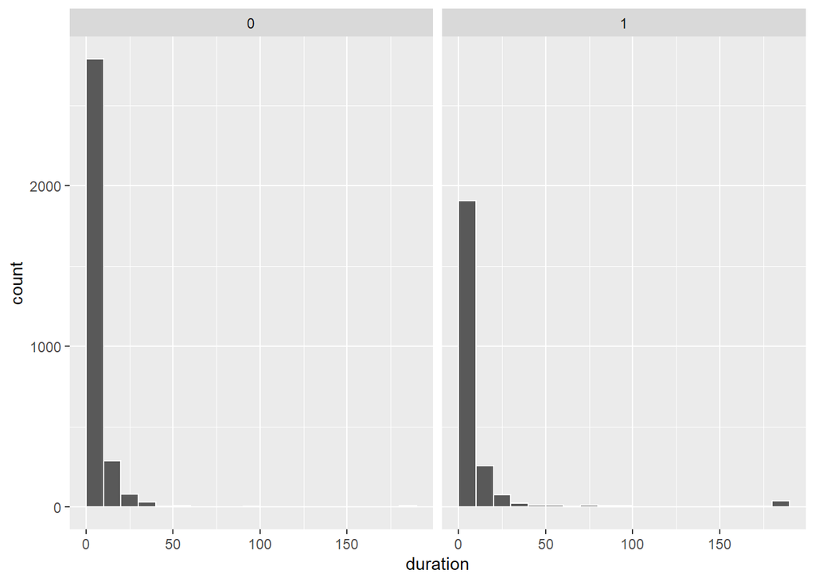

```r
ggplot(data = df, aes(x = duration)) +
  geom_histogram(binwidth = 10, color = "white", boundary = 0) +
  facet_wrap(~ highearn)
```

### Ploting log duration based on category

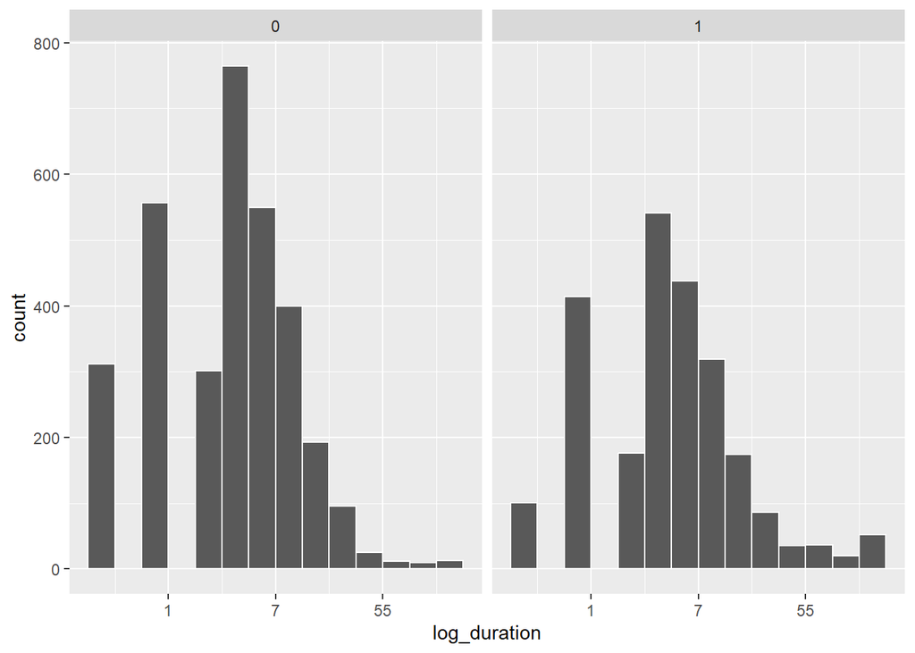

```r
ggplot(data = df, mapping = aes(x = log_duration)) +
  geom_histogram(binwidth = 0.5, color = "white", boundary = 0) +
   scale_x_continuous(labels = trans_format("exp", format = round)) +
  facet_wrap(~ highearn)
```

### Here we just calculate Mean

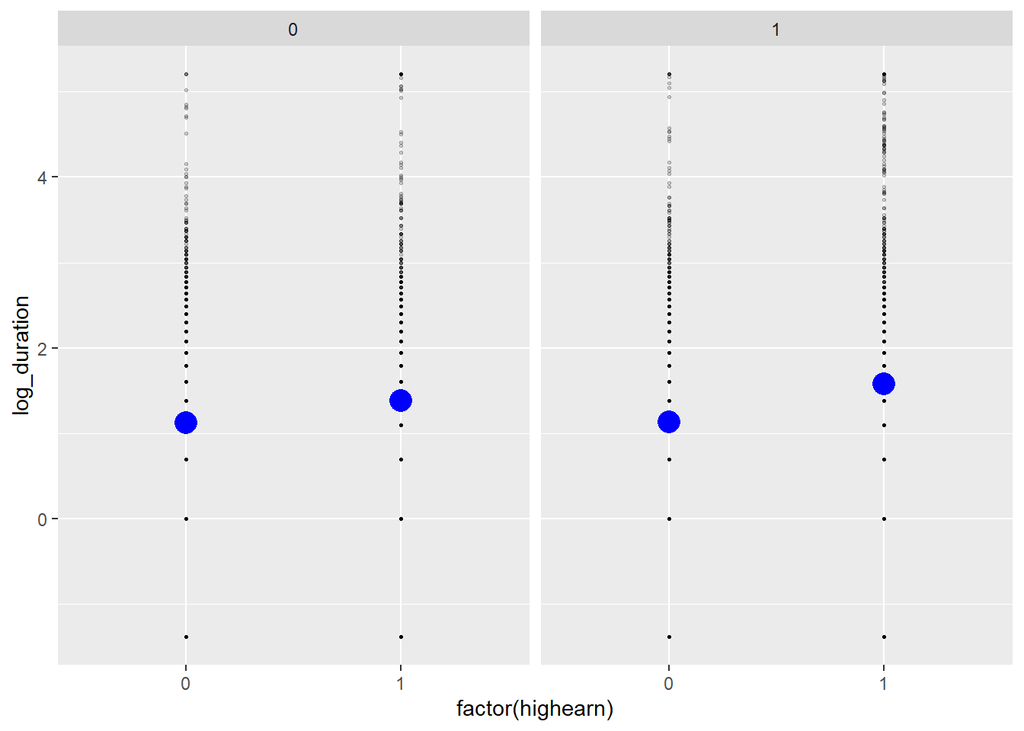

```r
ggplot(df, aes(x = factor(highearn), y = log_duration)) +
  geom_point(size = 0.5, alpha = 0.2) +
  stat_summary(geom = "point", fun = "mean", size = 5, color = "blue") +
  facet_wrap(vars(after_1980))
```

## 3.Basic Regression analysis to calculate the estimates without any control

### Basic Regression model

$$duration = \beta_0 + \beta_1 after1980 + \beta_2 highearn + \delta
afterchange \cdot highearn + u$$

```r
basic_model_1 <- lm(duration ~ after_1980 + highearn + after_1980*highearn, data = df)
tidy(basic_model_1)
```

| term | estimate | std.error | statistic | p.value |
| --- | --- | --- | --- | --- |
| (Intercept) | 6.2715543 | 0.5228724 | 11.9944256 | 9.513224e-33 |
| after_1980 | 0.7657738 | 0.7606973 | 1.0066735 | 3.141350e-01 |
| highearn | 4.9050475 | 0.8071237 | 6.0771945 | 1.303381e-09 |
| after_1980:highearn | 0.9512506 | 1.1654234 | 0.8162274 | 4.144046e-01 |

The notation $\delta$$1$ = 0.9513, indicates that the policy change might have increased the duration of benefits for high-income workers by about 0.9513 weeks more than for low-income workers. However, this effect is not statistically significant (p=0.414). The coefficient on after_1980 is small 0.7658 and statistically insignificant which means the increase in the earnings cap has no effect on duration for low-income workers.

$$\log(duration) = \beta_0 + \beta_1 after1980 + \beta_2 highearn +
\delta_1 afterchange \cdot highearn + u$$

```r
basic_model_2 <- lm(log(duration) ~ after_1980 + highearn + after_1980*highearn, data = df)
tidy(basic_model_2)
```

| term | estimate | std.error | statistic | p.value |
| --- | --- | --- | --- | --- |
| (Intercept) | 1.125615399 | 0.03073683 | 36.6210678 | 1.617413e-263 |
| after_1980 | 0.007657314 | 0.04471726 | 0.1712384 | 8.640424e-01 |
| highearn | 0.256478532 | 0.04744641 | 5.4056465 | 6.723704e-08 |
| after_1980:highearn | 0.190601200 | 0.06850891 | 2.7821376 | 5.418222e-03 |

The notation $\delta$ signifies that the average duration of workers’ compensation among high earners rose approximately by 19.06% due to the increased earnings cap. The coefficient on after_1980 is small 0.007 and statistically insignificant which means the increase in the earnings cap has no effect on duration for low-income workers.

## 4.regression adujstment procedure to evaluate the impact of policy change on the duration, and log_duration.

### Regression Adjustment Model 1

$$\text{duration} = \beta_0 + \beta_1 \text{after1980} + \beta_2
\text{highearn} + \delta_1 \text{afterchange} \cdot \text{highearn}
\\$$
$$+ \gamma_1\text{male} +
\gamma_2\text{married} + \gamma_3\text{age}^2 + \gamma_4\text{hosp} +
\gamma_5\text{indust} \\$$
$$+
\gamma_6\text{injtype} + \gamma_7\text{lprewage}+ u$$
### Creating a new column age squared

```r
df <- df %>% mutate(age_squared = age^2)
```

```r
adv_model_1 <- lm(duration ~ after_1980 + highearn +
after_1980*highearn + male + married + age_squared +
hosp + indust + injtype + lprewage, data =df)
print(summary(adv_model_1))
```

```
##
## Call:
## lm(formula = duration ~ after_1980 + highearn + after_1980 *
##     highearn + male + married + age_squared + hosp + indust +
##     injtype + lprewage, data = df)
##
## Residuals:
##     Min      1Q  Median      3Q     Max
## -27.603  -6.471  -2.251   1.503 181.142
##
## Coefficients:
##                       Estimate Std. Error t value Pr(>|t|)
## (Intercept)         -1.863e+01  7.171e+00  -2.598 0.009390 **
## after_1980           1.101e+00  7.031e-01   1.566 0.117441
## highearn            -1.100e+00  1.517e+00  -0.726 0.468082
## male                -9.995e-01  7.165e-01  -1.395 0.163113
## married              1.581e+00  6.286e-01   2.515 0.011938 *
## age_squared          3.412e-04  2.820e-04   1.210 0.226412
## hosp                 1.346e+01  6.296e-01  21.379  < 2e-16 ***
## indust2              7.637e-01  9.210e-01   0.829 0.407036
## indust3              2.781e+00  6.440e-01   4.318  1.6e-05 ***
## injtype2             5.904e+00  2.446e+00   2.414 0.015813 *
## injtype3             1.104e+00  1.454e+00   0.760 0.447436
## injtype4            -5.895e-01  1.580e+00  -0.373 0.709034
## injtype5             3.461e+00  1.454e+00   2.381 0.017308 *
## injtype6             3.725e-01  1.469e+00   0.254 0.799757
## injtype7             1.071e+01  3.241e+00   3.303 0.000962 ***
## injtype8            -1.464e-02  2.023e+00  -0.007 0.994227
## lprewage             3.454e+00  1.362e+00   2.536 0.011226 *
## after_1980:highearn  1.790e+00  1.088e+00   1.644 0.100192
## ---
## Signif. codes:  0 '***' 0.001 '**' 0.01 '*' 0.05 '.' 0.1 ' ' 1
##
## Residual standard error: 19.56 on 5329 degrees of freedom
##   (279 observations deleted due to missingness)
## Multiple R-squared:  0.1102, Adjusted R-squared:  0.1074
## F-statistic: 38.83 on 17 and 5329 DF,  p-value: < 2.2e-16
```

After controlling for all the X’s (male ,married , age_squared ,hosp,indust,injtype,lprewage), the coeffcicent of interation term comes out to be 1.79 whic is insignificant.

### Regression Adjustment Model 2

$$\log(\text{duration}) = \beta_0 + \beta_1 \text{after1980} + \beta_2
\text{highearn} + \delta_1 \text{afterchange} \cdot \text{highearn}
\\$$
$$+ \gamma_1\text{male} + \gamma_2\text{married} + \gamma_3\text{age}^2 +
\gamma_4\text{hosp} + \gamma_5\text{indust} \\$$
$$+ \gamma_6\text{injtype} +
\gamma_7\text{lprewage}+ u$$

```r
adv_model_2 <- lm(log_duration ~ after_1980 + highearn +
after_1980*highearn + male + married + age_squared + hosp
+ indust + injtype + lprewage, data =df)
print(summary(adv_model_2))
```

```
##
## Call:
## lm(formula = log_duration ~ after_1980 + highearn + after_1980 *
##     highearn + male + married + age_squared + hosp + indust +
##     injtype + lprewage, data = df)
##
## Residuals:
##     Min      1Q  Median      3Q     Max
## -4.0550 -0.7754  0.0930  0.7318  4.3620
##
## Coefficients:
##                       Estimate Std. Error t value Pr(>|t|)
## (Intercept)         -1.460e+00  4.216e-01  -3.463 0.000538 ***
## after_1980           4.937e-02  4.134e-02   1.194 0.232437
## highearn            -1.532e-01  8.916e-02  -1.718 0.085832 .
## male                -9.264e-02  4.213e-02  -2.199 0.027931 *
## married              6.771e-02  3.696e-02   1.832 0.067005 .
## age_squared          7.357e-05  1.658e-05   4.437 9.32e-06 ***
## hosp                 1.131e+00  3.702e-02  30.546  < 2e-16 ***
## indust2              1.831e-01  5.415e-02   3.380 0.000729 ***
## indust3              1.629e-01  3.787e-02   4.301 1.73e-05 ***
## injtype2             9.364e-01  1.438e-01   6.512 8.09e-11 ***
## injtype3             6.362e-01  8.547e-02   7.443 1.14e-13 ***
## injtype4             5.571e-01  9.288e-02   5.998 2.13e-09 ***
## injtype5             6.446e-01  8.547e-02   7.542 5.42e-14 ***
## injtype6             6.163e-01  8.634e-02   7.137 1.08e-12 ***
## injtype7             9.966e-01  1.906e-01   5.229 1.77e-07 ***
## injtype8             4.361e-01  1.190e-01   3.666 0.000248 ***
## lprewage             2.943e-01  8.005e-02   3.676 0.000239 ***
## after_1980:highearn  1.697e-01  6.400e-02   2.651 0.008043 **
## ---
## Signif. codes:  0 '***' 0.001 '**' 0.01 '*' 0.05 '.' 0.1 ' ' 1
##
## Residual standard error: 1.15 on 5329 degrees of freedom
##   (279 observations deleted due to missingness)
## Multiple R-squared:  0.1893, Adjusted R-squared:  0.1867
## F-statistic: 73.17 on 17 and 5329 DF,  p-value: < 2.2e-16
```

Combining the data set to contain (ky==0) We here combine the data set including the state of michigan state sample .

```r
dataset_combined <- dataset %>% rename(duration = durat,
log_duration = ldurat,after_1980 = afchnge)%>%
mutate(indust = as.factor(indust),injtype = as.factor(injtype))%>%
mutate(age_squared = age^2)
```

# 5. Robustness check

$$\log(\text{duration}) = \beta_0 +
\beta_1 \text{after1980} + \beta_2 \text{highearn}
+ \delta_1 \text{afterchange} \cdot \text{highearn} \\$$
$$+ \gamma_1\text{male} + \gamma_2\text{married} +
\gamma_3\text{age}^2 \\
+ \gamma_4\text{hosp} + \gamma_5\text{indust} \\$$
$$+ \gamma_6\text{injtype} +
\gamma_7\text{lprewage} \\
+ \delta_2 \text{after1980} \cdot \text{ky} + \delta_3 \text{ky} + u$$

```r
robust_model1 <- lm(log_duration ~ after_1980 + highearn +
after_1980*highearn + male + married + age_squared + hosp
+ indust + injtype + lprewage + ky +ky:after_1980, data =dataset_combined)
print(summary(robust_model1))
```

```
##
## Call:
## lm(formula = log_duration ~ after_1980 + highearn + after_1980 *
##     highearn + male + married + age_squared + hosp + indust +
##     injtype + lprewage + ky + ky:after_1980, data = dataset_combined)
##
## Residuals:
##     Min      1Q  Median      3Q     Max
## -4.7673 -0.7489  0.0699  0.7357  4.2709
##
## Coefficients:
##                       Estimate Std. Error t value Pr(>|t|)
## (Intercept)         -1.175e+00  4.514e-01  -2.603 0.009270 **
## after_1980           8.059e-02  6.422e-02   1.255 0.209597
## highearn            -1.326e-01  8.690e-02  -1.526 0.126941
## male                -1.438e-01  3.852e-02  -3.732 0.000192 ***
## married              4.594e-02  3.324e-02   1.382 0.167018
## age_squared          8.785e-05  1.501e-05   5.853 5.04e-09 ***
## hosp                 1.101e+00  3.346e-02  32.910  < 2e-16 ***
## indust2              2.640e-01  4.724e-02   5.588 2.38e-08 ***
## indust3              1.551e-01  3.370e-02   4.603 4.24e-06 ***
## injtype2             8.898e-01  1.333e-01   6.674 2.68e-11 ***
## injtype3             6.550e-01  7.936e-02   8.254  < 2e-16 ***
## injtype4             5.969e-01  8.558e-02   6.975 3.35e-12 ***
## injtype5             6.315e-01  7.956e-02   7.938 2.39e-15 ***
## injtype6             6.068e-01  8.025e-02   7.562 4.49e-14 ***
## injtype7             1.115e+00  1.612e-01   6.918 5.00e-12 ***
## injtype8             5.605e-01  1.080e-01   5.190 2.16e-07 ***
## lprewage             2.758e-01  7.919e-02   3.483 0.000499 ***
## ky                  -1.628e-01  5.932e-02  -2.745 0.006064 **
## after_1980:highearn  1.674e-01  5.887e-02   2.843 0.004476 **
## after_1980:ky       -2.950e-02  6.997e-02  -0.422 0.673382
## ---
## Signif. codes:  0 '***' 0.001 '**' 0.01 '*' 0.05 '.' 0.1 ' ' 1
##
## Residual standard error: 1.179 on 6802 degrees of freedom
##   (328 observations deleted due to missingness)
## Multiple R-squared:  0.1832, Adjusted R-squared:  0.1809
## F-statistic: 80.27 on 19 and 6802 DF,  p-value: < 2.2e-16
```

## DDD

$$\text{log(duration)}= \beta_0+ \beta_1*ky+ \beta_2*after1980_t+
\beta_3*highEarn_i+\\$$
$$\gamma_1(ky_s*after1980_t)+\gamma_2(ky*highearn)+
\gamma_2(after1980*highearn)+\\
\delta_1(ky*after1980*highearn)+ \psi*{X}+ u$$

Considering the entire dataset including Michigan, we need to account for state-specific and income-specific time trends that might influence compensation benefits. To do this, we use Triple Differences, which involves comparing the differences between Kentucky and Michigan data to eliminate these confounding factors.

```r
DDD= lm( duration ~ ky + after_1980 + highearn + ky*after_1980 + ky*highearn
         + after_1980*highearn + ky*after_1980*highearn + male + married
         + age_squared + hosp
+ indust + injtype + lprewage, data=dataset_combined)
summary(DDD)
```

```
##
## Call:
## lm(formula = duration ~ ky + after_1980 + highearn + ky * after_1980 +
##     ky * highearn + after_1980 * highearn + ky * after_1980 *
##     highearn + male + married + age_squared + hosp + indust +
##     injtype + lprewage, data = dataset_combined)
##
## Residuals:
##     Min      1Q  Median      3Q     Max
## -41.970  -7.650  -2.916   1.287 179.648
##
## Coefficients:
##                          Estimate Std. Error t value Pr(>|t|)
## (Intercept)            -1.483e+01  8.685e+00  -1.708 0.087693 .
## ky                     -3.296e+00  1.295e+00  -2.545 0.010941 *
## after_1980              2.708e+00  1.421e+00   1.906 0.056712 .
## highearn                5.330e-01  2.303e+00   0.231 0.816988
## male                   -1.865e+00  7.407e-01  -2.518 0.011813 *
## married                 8.539e-01  6.387e-01   1.337 0.181296
## age_squared             8.690e-04  2.888e-04   3.009 0.002634 **
## hosp                    1.380e+01  6.430e-01  21.468  < 2e-16 ***
## indust2                 2.311e+00  9.102e-01   2.539 0.011141 *
## indust3                 2.485e+00  6.476e-01   3.838 0.000125 ***
## injtype2                6.412e+00  2.562e+00   2.503 0.012331 *
## injtype3                1.889e+00  1.525e+00   1.239 0.215275
## injtype4                5.805e-01  1.644e+00   0.353 0.723992
## injtype5                4.376e+00  1.528e+00   2.863 0.004204 **
## injtype6                8.398e-01  1.542e+00   0.545 0.585941
## injtype7                1.297e+01  3.101e+00   4.181 2.94e-05 ***
## injtype8                2.665e+00  2.075e+00   1.284 0.199142
## lprewage                3.250e+00  1.522e+00   2.136 0.032710 *
## ky:after_1980          -1.636e+00  1.638e+00  -0.999 0.317866
## ky:highearn            -1.269e+00  1.975e+00  -0.643 0.520521
## after_1980:highearn     5.057e-01  2.576e+00   0.196 0.844378
## ky:after_1980:highearn  1.361e+00  2.868e+00   0.474 0.635199
## ---
## Signif. codes:  0 '***' 0.001 '**' 0.01 '*' 0.05 '.' 0.1 ' ' 1
##
## Residual standard error: 22.64 on 6800 degrees of freedom
##   (328 observations deleted due to missingness)
## Multiple R-squared:  0.09577,    Adjusted R-squared:  0.09298
## F-statistic:  34.3 on 21 and 6800 DF,  p-value: < 2.2e-16
```

here we see that the triple interaction term comes out to be 1.36 positive but insignificant, when controlling for all the other possible X’s.

# 6. Generating Graph

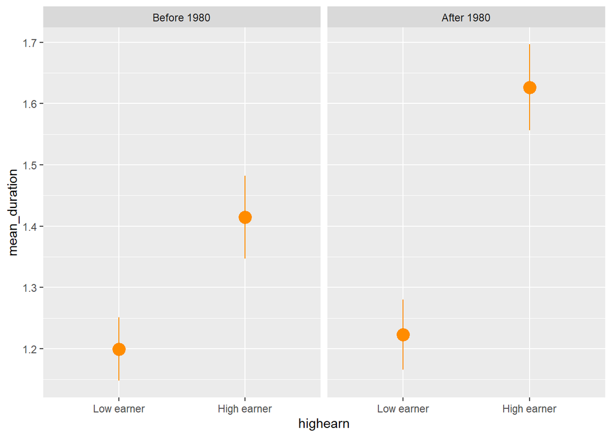

```r
graph_data <- dataset_combined %>%
   mutate(highearn = factor(highearn, labels = c("Low earner", "High earner")),
         after_1980 = factor(after_1980, labels = c("Before 1980", "After 1980"))) %>%
  group_by(highearn, after_1980) %>%
  summarize(mean_duration = mean(log_duration),
            se_duration = sd(log_duration) / sqrt(n()),
            upper = mean_duration + (1.96 * se_duration),
            lower = mean_duration + (-1.96 * se_duration))
ggplot(graph_data, aes(x = highearn, y = mean_duration)) +
  geom_pointrange(aes(ymin = lower, ymax = upper),
                  color = "darkorange", size = 1) +
  facet_wrap(vars(after_1980))
```

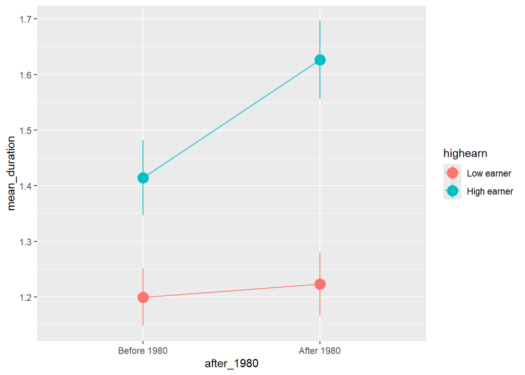

```r
ggplot(graph_data, aes(x = after_1980, y = mean_duration, color = highearn)) +
  geom_pointrange(aes(ymin = lower, ymax = upper), size = 1) +
  # The group = highearn here makes it so the lines go across categories
  geom_line(aes(group = highearn))
```

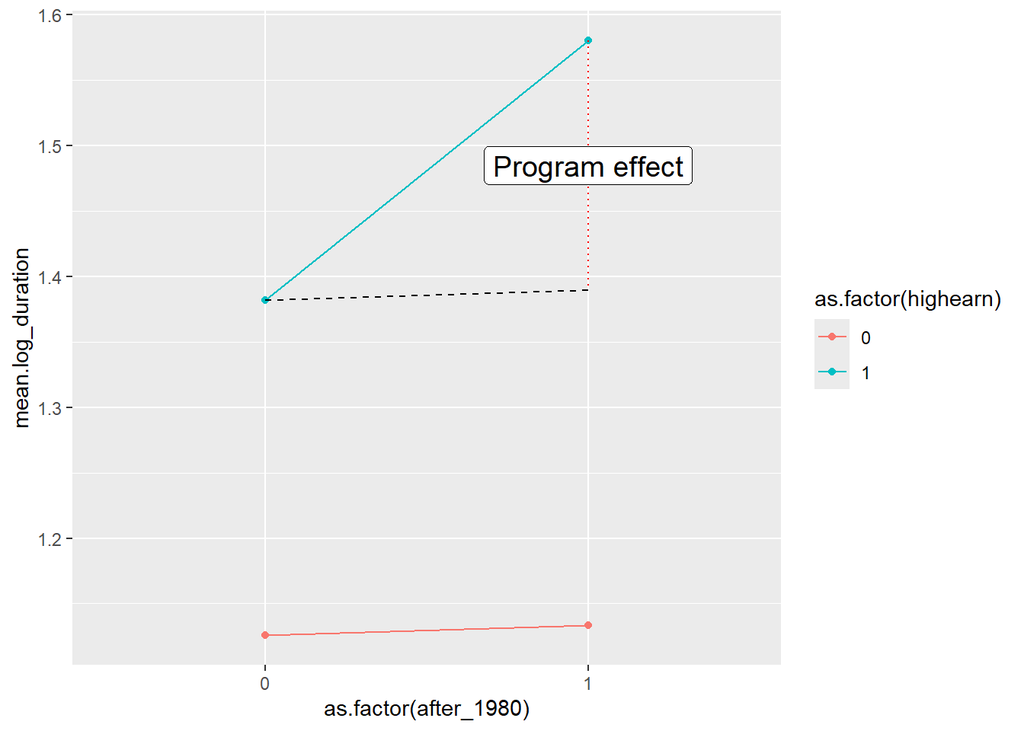

```r
ggplot(difr_log, aes(x = as.factor(after_1980),
                  y = mean.log_duration,
                  color = as.factor(highearn)))+
  geom_point() +
  geom_line(aes(group = as.factor(highearn))) +
  annotate(geom = "segment", x = "0", xend = "1",
           y = pre_treatement_treated_group_log, yend =
             post_treatement_treated_group_log - policy_effect_log,
           linetype = "dashed", color = "black") +
  annotate(geom = "segment", x = "1", xend = "1",
           y = post_treatement_treated_group_log, yend =
             post_treatement_treated_group_log - policy_effect_log,
           linetype = "dotted", color = "red") +
  annotate(geom = "label", x = "1", y = post_treatement_treated_group_log
           - (policy_effect_log / 2),
           label = "Program effect", size = 5)
```

```r
modelsummary(list(basic_model_2,adv_model_2,DDD,robust_model1))
```

|  | (1) | (2) | (3) | (4) |
| --- | --- | --- | --- | --- |
| (Intercept) | 1.126 | -1.460 | -14.834 | -1.175 |
|  | (0.031) | (0.422) | (8.685) | (0.451) |
| after_1980 | 0.008 | 0.049 | 2.708 | 0.081 |
|  | (0.045) | (0.041) | (1.421) | (0.064) |
| highearn | 0.256 | -0.153 | 0.533 | -0.133 |
|  | (0.047) | (0.089) | (2.303) | (0.087) |
| after_1980 × highearn | 0.191 | 0.170 | 0.506 | 0.167 |
|  | (0.069) | (0.064) | (2.576) | (0.059) |
| male |  | -0.093 | -1.865 | -0.144 |
|  |  | (0.042) | (0.741) | (0.039) |
| married |  | 0.068 | 0.854 | 0.046 |
|  |  | (0.037) | (0.639) | (0.033) |
| age_squared |  | 0.000 | 0.001 | 0.000 |
|  |  | (0.000) | (0.000) | (0.000) |
| hosp |  | 1.131 | 13.804 | 1.101 |
|  |  | (0.037) | (0.643) | (0.033) |
| indust2 |  | 0.183 | 2.311 | 0.264 |
|  |  | (0.054) | (0.910) | (0.047) |
| indust3 |  | 0.163 | 2.485 | 0.155 |
|  |  | (0.038) | (0.648) | (0.034) |
| injtype2 |  | 0.936 | 6.412 | 0.890 |
|  |  | (0.144) | (2.562) | (0.133) |
| injtype3 |  | 0.636 | 1.889 | 0.655 |
|  |  | (0.085) | (1.525) | (0.079) |
| injtype4 |  | 0.557 | 0.581 | 0.597 |
|  |  | (0.093) | (1.644) | (0.086) |
| injtype5 |  | 0.645 | 4.376 | 0.631 |
|  |  | (0.085) | (1.528) | (0.080) |
| injtype6 |  | 0.616 | 0.840 | 0.607 |
|  |  | (0.086) | (1.542) | (0.080) |
| injtype7 |  | 0.997 | 12.966 | 1.115 |
|  |  | (0.191) | (3.101) | (0.161) |
| injtype8 |  | 0.436 | 2.665 | 0.561 |
|  |  | (0.119) | (2.075) | (0.108) |
| lprewage |  | 0.294 | 3.250 | 0.276 |
|  |  | (0.080) | (1.522) | (0.079) |
| ky |  |  | -3.296 | -0.163 |
|  |  |  | (1.295) | (0.059) |
| ky × after_1980 |  |  | -1.636 |  |
|  |  |  | (1.638) |  |
| ky × highearn |  |  | -1.269 |  |
|  |  |  | (1.975) |  |
| ky × after_1980 × highearn |  |  | 1.361 |  |
|  |  |  | (2.868) |  |
| after_1980 × ky |  |  |  | -0.029 |
|  |  |  |  | (0.070) |
| Num.Obs. | 5626 | 5347 | 6822 | 6822 |
| R2 | 0.021 | 0.189 | 0.096 | 0.183 |
| R2 Adj. | 0.020 | 0.187 | 0.093 | 0.181 |
| AIC | 18654.0 | 16688.7 | 61949.1 | 21623.7 |
| BIC | 18687.2 | 16813.8 | 62106.1 | 21767.0 |
| Log.Lik. | -9321.997 | -8325.371 | -30951.538 | -10790.826 |
| RMSE | 1.27 | 1.15 | 22.60 | 1.18 |